# بخش اول - MNIST

## محمدرضا کیانی - ۸۱۰۱۹۴۳۸۸

 ابتدا داده‌ها را با کمک پانداز می‌خوانم:

```python
import pandas as pd

train_data = pd.read_csv("dataset/MNIST/train_data.csv", header=None)
train_label = pd.read_csv("dataset/MNIST/train_label.csv", header=None)[0]
print("Train data size:", len(train_data))

test_data = pd.read_csv("dataset/MNIST/test_data.csv", header=None)
test_label = pd.read_csv("dataset/MNIST/test_label.csv", header=None)[0]
print("Test data size:", len(test_data))
```

```
Train data size: 2000
Test data size: 200
```

 ۰- رقم یکان شماره‌ی دانشجویی من عدد ۸ است. بنابراین ابتدا به دنبال یک رقم ۸ می‌گردم:

```python
eight_index = train_label[train_label==8].sample(1).index[0]
print("Selected Index:", eight_index)
```

```
Selected Index: 1766
```

 سپس آن را نمایش می‌دهم:

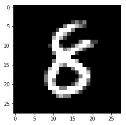

```python
from PIL import Image
import matplotlib.pyplot as plt
%matplotlib inline

img = Image.new('L', (28, 28))
img.putdata(train_data.iloc[eight_index])
plt.imshow(img)
```

### K-Nearest Neighbors

 ۱- در این روش، ابتدا فیچرهای داده‌های ترین و برچسب آن‌ها ذخیره می‌شود و سپس به ازای هر ورودی، k تا از همسایه‌های ان بررسی می‌شوند. اگر اکثریت آنها بر این اتفاق داشته باشند که این داده مربوط به یک برچسب هست، نوع داده مشخص میشود. چالش اصلی در این روش پیدا کردن k مناسب برای کمینه کردن خطا و دقت بیشتر است و برای این از روش elbow استقاده می‌کنیم که مشخص کند کجا بیشترین شکستگی اتفاق افتاده است.

 ۲- با اجرای کد زیر الگوریتم KNN بر روی داده‌هایمان اجرا می‌شود دقت آن ثبت می‌گردد.

```python
from sklearn.neighbors import KNeighborsClassifier
from sklearn.metrics import accuracy_score

n_neighbors = range(1, 30)
train_accuracy = []
test_accuracy = []
print ("K-Nearest Neighbors accuracy score")
for n in n_neighbors:
    neigh = KNeighborsClassifier(n_neighbors=n)
    neigh.fit(train_data, train_label)

    pred = neigh.predict(train_data)
    train_accuracy.append(accuracy_score(train_label, pred))

    pred = neigh.predict(test_data)
    test_accuracy.append(accuracy_score(test_label, pred))

    print ("\tFor n_neighbors =", n, "train:", train_accuracy[-1], "test:", test_accuracy[-1])
```

```
K-Nearest Neighbors accuracy score
	For n_neighbors = 1 train: 1.0 test: 0.86
	For n_neighbors = 2 train: 0.958 test: 0.87
	For n_neighbors = 3 train: 0.955 test: 0.895
	For n_neighbors = 4 train: 0.9485 test: 0.9
	For n_neighbors = 5 train: 0.9345 test: 0.89
	For n_neighbors = 6 train: 0.9295 test: 0.885
	For n_neighbors = 7 train: 0.9255 test: 0.9
	For n_neighbors = 8 train: 0.9245 test: 0.895
	For n_neighbors = 9 train: 0.921 test: 0.9
	For n_neighbors = 10 train: 0.9195 test: 0.895
	For n_neighbors = 11 train: 0.9165 test: 0.9
	For n_neighbors = 12 train: 0.9145 test: 0.91
	For n_neighbors = 13 train: 0.9095 test: 0.9
	For n_neighbors = 14 train: 0.91 test: 0.9
	For n_neighbors = 15 train: 0.9045 test: 0.885
	For n_neighbors = 16 train: 0.903 test: 0.9
	For n_neighbors = 17 train: 0.898 test: 0.895
	For n_neighbors = 18 train: 0.897 test: 0.89
	For n_neighbors = 19 train: 0.892 test: 0.88
	For n_neighbors = 20 train: 0.889 test: 0.88
	For n_neighbors = 21 train: 0.8875 test: 0.885
	For n_neighbors = 22 train: 0.8865 test: 0.885
	For n_neighbors = 23 train: 0.881 test: 0.885
	For n_neighbors = 24 train: 0.879 test: 0.88
	For n_neighbors = 25 train: 0.8795 test: 0.88
	For n_neighbors = 26 train: 0.876 test: 0.87
	For n_neighbors = 27 train: 0.8745 test: 0.87
	For n_neighbors = 28 train: 0.8735 test: 0.86
	For n_neighbors = 29 train: 0.875 test: 0.855
```

 ۳- نمودار دقت به ازای مقادیر مختلف neighbors_n:

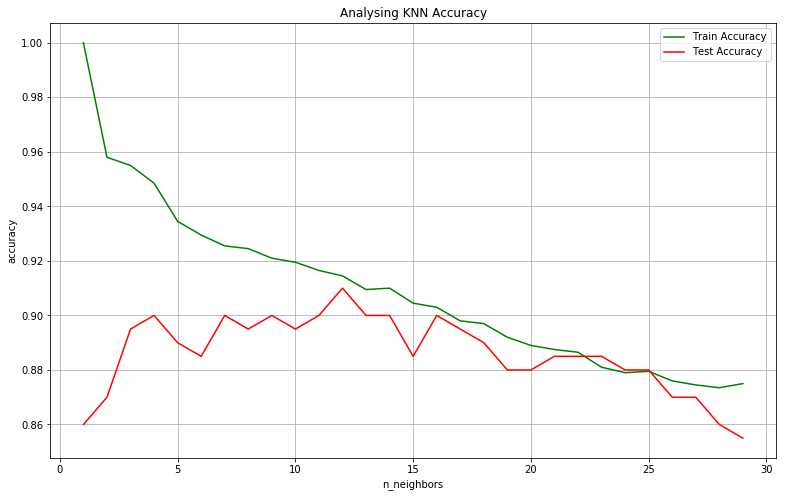

```python
plt.figure(figsize=(13,8))
plt.plot(n_neighbors, train_accuracy, '-r', label='Train Accuracy', c='green')
plt.plot(n_neighbors, test_accuracy, '-r', label='Test Accuracy', c='red')
plt.xlabel("n_neighbors")
plt.ylabel("accuracy")
plt.title('Analysing KNN Accuracy')
plt.legend()
plt.grid()
plt.show()
```

 بنابراین نقطه‌ی بهنیه‌ی آن برای تست، به ازای n_neighbors=12 اتفاق می‌افتد که دقت ۹۱٪ است.

 ۴- در ابتدا که تعداد دسته‌ها کم است ما نیز خطای کمی داریم، مثلا در حالت n_neighbors=1 که یک دسته بیشتر نداریم با دقت ۱۰۰٪ روبهرو هستیم که چرا که هر داده دقیقا از روی خودش به برچسب درست می‌رسد. اما با زیاد شدن n_neighbors با افزایش خطا روبه‌رو هستیم و چرا که در تعیین نوع برچسب یک داده، داده‌های بیشتری دخیل هستند و به تبع با افزایش خطا روبهرو می‌شویم.

 ۵- برای همان عددی که یکان شماره‌ی دانشجویی‌م بود و برای n_neighbors=12 داده‌های همسایه‌ی آن را می‌کشم:

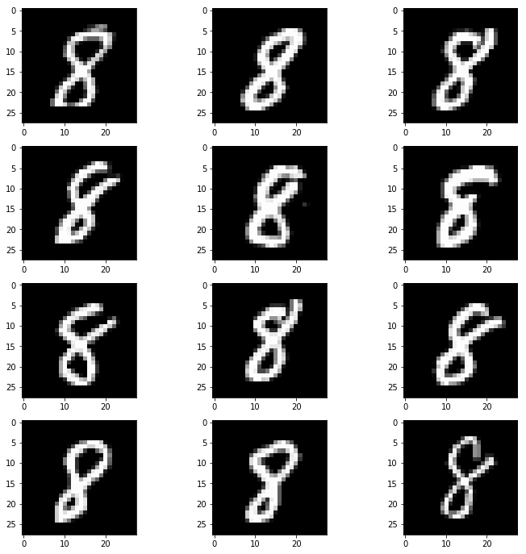

```python
neigh = KNeighborsClassifier(n_neighbors=12)
neigh.fit(train_data, train_label)

neighbor_indexes = neigh.kneighbors([train_data.iloc[eight_index]], n_neighbors=12, return_distance=False)[0]
_, axs = plt.subplots(4, 3, figsize=(12, 12))
for i, neighbor_index in enumerate(neighbor_indexes):
    img = Image.new('L', (28, 28))
    img.putdata(train_data.iloc[neighbor_index])
    axs[int(i/3), i%3].imshow(img)
```

 ۶- یکی از مشکلات این الگوریتم سرعت پایین آن در هنگام تست است. در واقع پیاده‌سازی آن ساده است اما با بزرگ‌شدن تعداد داده‌ها، سرعت و بازده این الگوریتم به سرعت کم می‌شود. یکی از مشکلات و چالش‌های دیگر آن نیز به دست آوردن تعداد بهنیه‌ی همسایه‌ها است.

### Decision Tree

 ۷- درخت تصمیم روشی است که در آن بر اساس یک سری شرط بر روی فیچرهایمان به تصمیم نهایی می‌رسیم. یعنی در واقع ساختاری را داریم که در آن الگویی میان حالت‌های مختلف فیچر ها به دست آمده و ما بر اساس آن الگو‌ها می‌توانیم نوع خروجی مان را تعیین کنیم. فیچرهایی که Information Gain بیشتری به ما می‌دهند، اولین انتخاب‌های ما برای شکستن درخت تصمیم می‌باشند و سپس با فرض مقادیر انتخاب شده، به سراغ فیچرهای بعدی می‌رویم. در واقع هر نود در درخت تصمیم، مانند یک تست می‌باشد و ما با امتحان کردن چندین تست متفاوت بر روی داده‌ی جدید، حالت نهایی آن را پیشبینی می‌کنیم.

 ۸- درخت تصمیم را در کد زیر بر روی داده‌های MNIST اجرا می‌کنم:

```python
from sklearn.tree import DecisionTreeClassifier

dt = DecisionTreeClassifier()
dt.fit(train_data, train_label)

pred = dt.predict(train_data)
train_accuracy = accuracy_score(train_label, pred)

pred = dt.predict(test_data)
test_accuracy = accuracy_score(test_label, pred)

print("Decision Tree accuracy score")
print("\ttrain:", train_accuracy, "test:", test_accuracy)
```

```
Decision Tree accuracy score
	train: 1.0 test: 0.72
```

 ۹- برای tune کردن ارتفاع درخت:

```python
depth_range = range(1, 25)
train_accuracy = []
test_accuracy = []
print("Decision Tree accuracy score")
for depth in depth_range:
    dt = DecisionTreeClassifier(max_depth=depth)
    dt.fit(train_data, train_label)

    pred = dt.predict(train_data)
    train_accuracy.append(accuracy_score(train_label, pred))

    pred = dt.predict(test_data)
    test_accuracy.append(accuracy_score(test_label, pred))

    print("\tdepth:", depth, "train:", train_accuracy[-1], "test:", test_accuracy[-1])
```

```
Decision Tree accuracy score
	depth: 1 train: 0.165 test: 0.155
	depth: 2 train: 0.2715 test: 0.26
	depth: 3 train: 0.4045 test: 0.35
	depth: 4 train: 0.563 test: 0.495
	depth: 5 train: 0.6675 test: 0.605
	depth: 6 train: 0.747 test: 0.635
	depth: 7 train: 0.816 test: 0.68
	depth: 8 train: 0.8825 test: 0.71
	depth: 9 train: 0.9355 test: 0.735
	depth: 10 train: 0.9695 test: 0.73
	depth: 11 train: 0.987 test: 0.705
	depth: 12 train: 0.996 test: 0.715
	depth: 13 train: 0.9985 test: 0.715
	depth: 14 train: 0.9995 test: 0.735
	depth: 15 train: 0.9995 test: 0.695
	depth: 16 train: 1.0 test: 0.745
	depth: 17 train: 1.0 test: 0.71
	depth: 18 train: 1.0 test: 0.71
	depth: 19 train: 1.0 test: 0.7
	depth: 20 train: 1.0 test: 0.7
	depth: 21 train: 1.0 test: 0.735
	depth: 22 train: 1.0 test: 0.725
	depth: 23 train: 1.0 test: 0.71
	depth: 24 train: 1.0 test: 0.725
```

 کشیدن نمودار دقت به ازای هر ارتفاع:

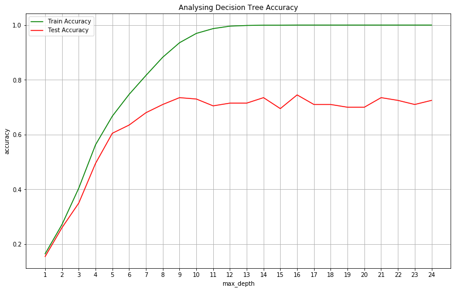

```python
plt.figure(figsize=(13,8))
plt.plot(depth_range, train_accuracy, '-r', label='Train Accuracy', c='green')
plt.plot(depth_range, test_accuracy, '-r', label='Test Accuracy', c='red')
plt.xticks(depth_range)
plt.xlabel("max_depth")
plt.ylabel("accuracy")
plt.title('Analysing Decision Tree Accuracy')
plt.legend()
plt.grid()
plt.show()
```

 با توجه به نمودار بالا، از حداکثر ارتفاع ۱۲ به بعد، ما به دقت ۱۰۰٪ روی دادههای train می‌رسیم که نشان می‌دهد ارتفاع درخت از این عدد بیشتر نمی‌تواند باشد. لذا من ارتفاع ۹ را با دقت ۷۳.۵٪ انتخاب می‌کنم که هم درخت به حداکثر ارتفاع ممکن نرسیده و هم دقت ۱۰۰٪ روی داده‌ی train نداریم و به نوعی خطر overfit احتمال کمتری دارد.

 ۱۰- درخت برای حداکثر ارتفاع گفته شده یعنی ۹ را می‌کشم و در فایل dt.png ذخیره می‌کنم.

```python
from sklearn.tree import export_graphviz
import pydotplus

dt = DecisionTreeClassifier(max_depth=9)
dt.fit(train_data, train_label)
dot_data = export_graphviz(dt, out_file=None)
graph = pydotplus.graph_from_dot_data(dot_data)
graph.write_png("dt.png")
```

```
True
```

 با توجه به عریض بودن زیاد این شکل، یک قید حداکثر شکستگی برای یک نود را روی مسئله می‌گذارم تا درخت قابل نمایش‌تر باشد:

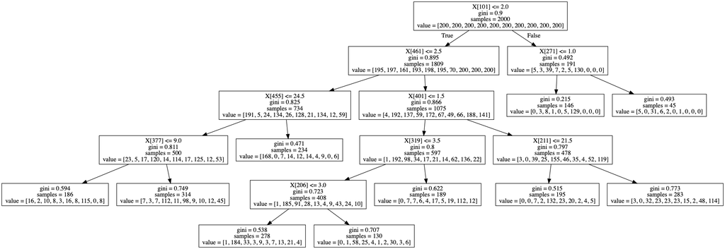

```python
from sklearn.tree import export_graphviz
import pydotplus

dt = DecisionTreeClassifier(max_depth=9, max_leaf_nodes=10)
dt.fit(train_data, train_label)
dot_data = export_graphviz(dt, out_file=None)
graph = pydotplus.graph_from_dot_data(dot_data)
Image(graph.create_png())
```

 ۱۱- overfit هنگامی در درخت تصمیم اتفاق می‌افتد که درخت طوری ساخته شود که روی داده‌های train دقت بسیار بالایی داشته باشد مثل ۱۰۰٪ چرا که با این کار درخت نود‌ها و شاخه‌هایی را دارد که قوانین عجیبی تنها برای ارضا کردن دقت روی داده‌ی train دارد. برای مثال در قسمت ۹ که روی حداکثر ارتفاع محدودیت وجود دارد، از یک جایی به بعد دیگر شاهد اختلاف دقت روی داده‌ی train نسبت به داده‌ی test هستیم که نمودی از overfit است.

### Random Forest

 ۱۲- در این روش، از روی داده‌های train ما چندین Decision Tree می‌سازیم و جواب نهایی ما روی داده‌ی تست، میانگین جواب‌ها (در مسئله‌ی regression) و یا جوابی که اکثریت آن را انتخاب کرده باشند (در مسائل classification) می‌باشد. جنگل تصادفی، خطای درخت تصمیم در overfit کردن را تا حدی حل می‌کند.

 ۱۳- حل مسئله با جنگل تصادفی:

```python
from sklearn.ensemble import RandomForestClassifier

rf = RandomForestClassifier(n_estimators=10)
rf.fit(train_data, train_label)

pred = dt.predict(train_data)
train_accuracy = accuracy_score(train_label, pred)

pred = dt.predict(test_data)
test_accuracy = accuracy_score(test_label, pred)

print("Random Forest accuracy score")
print("\ttrain:", train_accuracy, "test:", test_accuracy)
```

```
Random Forest accuracy score
	train: 0.5775 test: 0.555
```

 ۱۴- بررسی پارامتر ارتفاع درخت روی جنگل:

```python
depth_range = range(1, 25)
train_accuracy = []
test_accuracy = []
print("Random Forest accuracy score")
for depth in depth_range:
    rf = RandomForestClassifier(n_estimators=10, max_depth=depth)
    rf.fit(train_data, train_label)

    pred = rf.predict(train_data)
    train_accuracy.append(accuracy_score(train_label, pred))

    pred = rf.predict(test_data)
    test_accuracy.append(accuracy_score(test_label, pred))

    print("\tdepth:", depth, "train:", train_accuracy[-1], "test:", test_accuracy[-1])
```

```
Random Forest accuracy score
	depth: 1 train: 0.475 test: 0.415
	depth: 2 train: 0.535 test: 0.505
	depth: 3 train: 0.6675 test: 0.64
	depth: 4 train: 0.762 test: 0.67
	depth: 5 train: 0.857 test: 0.735
	depth: 6 train: 0.8925 test: 0.785
	depth: 7 train: 0.934 test: 0.78
	depth: 8 train: 0.9645 test: 0.82
	depth: 9 train: 0.9855 test: 0.795
	depth: 10 train: 0.9925 test: 0.82
	depth: 11 train: 0.9945 test: 0.805
	depth: 12 train: 0.9975 test: 0.815
	depth: 13 train: 0.9985 test: 0.815
	depth: 14 train: 0.999 test: 0.835
	depth: 15 train: 0.9995 test: 0.835
	depth: 16 train: 0.9995 test: 0.815
	depth: 17 train: 0.9995 test: 0.855
	depth: 18 train: 0.998 test: 0.82
	depth: 19 train: 0.997 test: 0.835
	depth: 20 train: 0.9985 test: 0.805
	depth: 21 train: 0.9985 test: 0.77
	depth: 22 train: 0.9985 test: 0.835
	depth: 23 train: 0.9955 test: 0.845
	depth: 24 train: 0.999 test: 0.79
```

 کشیدن نمودار دقت به ازای هر ارتفاع:

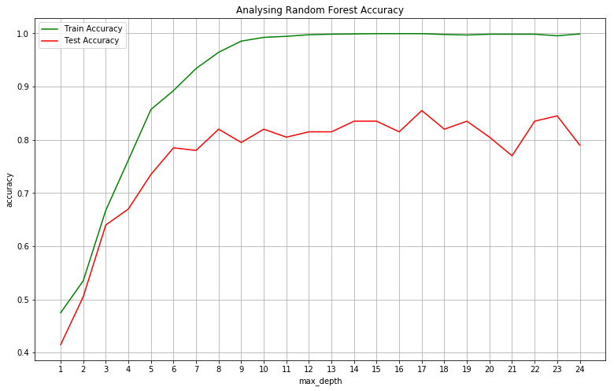

```python
plt.figure(figsize=(13,8))
plt.plot(depth_range, train_accuracy, '-r', label='Train Accuracy', c='green')
plt.plot(depth_range, test_accuracy, '-r', label='Test Accuracy', c='red')
plt.xticks(depth_range)
plt.xlabel("max_depth")
plt.ylabel("accuracy")
plt.title('Analysing Random Forest Accuracy')
plt.legend()
plt.grid()
plt.show()
```

 ۱۵- بررسی سایر پارامترها:  
 تعداد درخت یا n_estimators: پارامتری است که در آن تعداد درخت‌های جنگلمان را مشخص می‌کنیم.  
 min_sample_split: پارامتری است که در آن مشخص می‌شود حداقل چند نمونه‌ی ورودی لازم است تا هر نود درونی، تقسیم یا split شود به نودهای دیگر.  
 max_feature: حداکثر تعداد فیچرهایی که برای هر تقسیم یاsplit باید بررسی شوند.

 بررسی n_estimators که نشان می‌دهد حداقل ۵ درخت برای تصمیم‌گیری لازم است و تعداد ۱۲ تعداد خوبی است.

[output not shown]

[figure not shown]

```python
n_estimators = range(1, 20)
train_accuracy = []
test_accuracy = []
print("Random Forest accuracy score")
for m in n_estimators:
    rf = RandomForestClassifier(n_estimators=n)
    rf.fit(train_data, train_label)

    pred = rf.predict(train_data)
    train_accuracy.append(accuracy_score(train_label, pred))

    pred = rf.predict(test_data)
    test_accuracy.append(accuracy_score(test_label, pred))

    print("\tn:", n, "train:", train_accuracy[-1], "test:", test_accuracy[-1])

plt.figure(figsize=(13,8))
plt.plot(n_estimators, train_accuracy, '-r', label='Train Accuracy', c='green')
plt.plot(n_estimators, test_accuracy, '-r', label='Test Accuracy', c='red')
plt.xticks(n_estimators)
plt.xlabel("n_estimators")
plt.ylabel("accuracy")
plt.title('Analysing Random Forest n_estimators affect on accuracy')
plt.legend()
plt.grid()
plt.show()
```

 بررسی min_sample_split که نشان می‌دهد با افزایش این پارامتر دقت روی داده‌ی ترین کم شده و تاثیر خطی‌ای روی داده‌ی تست ندارد. مثلا در شکل پایین، مقدار ۷ برای این پارامتر به نظر مناسب است.

```
Random Forest accuracy score
	min_sample_splits: 2 train: 0.9995 test: 0.83
	min_sample_splits: 3 train: 0.9985 test: 0.815
	min_sample_splits: 4 train: 0.996 test: 0.855
	min_sample_splits: 5 train: 0.996 test: 0.84
	min_sample_splits: 6 train: 0.9945 test: 0.86
	min_sample_splits: 7 train: 0.9945 test: 0.87
	min_sample_splits: 8 train: 0.9885 test: 0.86
	min_sample_splits: 9 train: 0.9895 test: 0.82
	min_sample_splits: 10 train: 0.988 test: 0.835
	min_sample_splits: 11 train: 0.9815 test: 0.85
	min_sample_splits: 12 train: 0.981 test: 0.84
	min_sample_splits: 13 train: 0.978 test: 0.84
	min_sample_splits: 14 train: 0.9795 test: 0.86
	min_sample_splits: 15 train: 0.982 test: 0.85
	min_sample_splits: 16 train: 0.9745 test: 0.81
	min_sample_splits: 17 train: 0.969 test: 0.82
	min_sample_splits: 18 train: 0.9685 test: 0.83
	min_sample_splits: 19 train: 0.967 test: 0.82
	min_sample_splits: 20 train: 0.9635 test: 0.845
	min_sample_splits: 21 train: 0.9595 test: 0.82
	min_sample_splits: 22 train: 0.956 test: 0.815
	min_sample_splits: 23 train: 0.965 test: 0.82
	min_sample_splits: 24 train: 0.961 test: 0.825
```

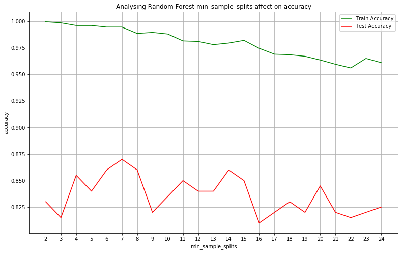

```python
min_sample_splits = range(2, 25)
train_accuracy = []
test_accuracy = []
print("Random Forest accuracy score")
for n in min_sample_splits:
    rf = RandomForestClassifier(n_estimators=12, min_samples_split=n)
    rf.fit(train_data, train_label)

    pred = rf.predict(train_data)
    train_accuracy.append(accuracy_score(train_label, pred))

    pred = rf.predict(test_data)
    test_accuracy.append(accuracy_score(test_label, pred))

    print("\tmin_sample_splits:", n, "train:", train_accuracy[-1], "test:", test_accuracy[-1])

plt.figure(figsize=(13,8))
plt.plot(min_sample_splits, train_accuracy, '-r', label='Train Accuracy', c='green')
plt.plot(min_sample_splits, test_accuracy, '-r', label='Test Accuracy', c='red')
plt.xticks(min_sample_splits)
plt.xlabel("min_sample_splits")
plt.ylabel("accuracy")
plt.title('Analysing Random Forest min_sample_splits affect on accuracy')
plt.legend()
plt.grid()
plt.show()
```

```
Random Forest accuracy score
	max_feature: 1 train: 0.9965 test: 0.735
	max_feature: 2 train: 0.9985 test: 0.79
	max_feature: 3 train: 0.998 test: 0.775
	max_feature: 4 train: 0.998 test: 0.8
	max_feature: 5 train: 0.997 test: 0.775
	max_feature: 6 train: 0.999 test: 0.8
	max_feature: 7 train: 0.998 test: 0.795
	max_feature: 8 train: 0.9995 test: 0.81
	max_feature: 9 train: 0.998 test: 0.81
	max_feature: 10 train: 0.999 test: 0.81
	max_feature: 11 train: 0.9975 test: 0.78
	max_feature: 12 train: 0.999 test: 0.815
	max_feature: 13 train: 0.997 test: 0.79
	max_feature: 14 train: 0.998 test: 0.805
	max_feature: 15 train: 0.998 test: 0.79
	max_feature: 16 train: 0.999 test: 0.775
	max_feature: 17 train: 0.999 test: 0.815
	max_feature: 18 train: 0.999 test: 0.795
	max_feature: 19 train: 0.999 test: 0.82
	max_feature: 20 train: 0.998 test: 0.815
	max_feature: 21 train: 0.999 test: 0.855
	max_feature: 22 train: 0.999 test: 0.825
	max_feature: 23 train: 0.9975 test: 0.845
	max_feature: 24 train: 0.998 test: 0.805
```

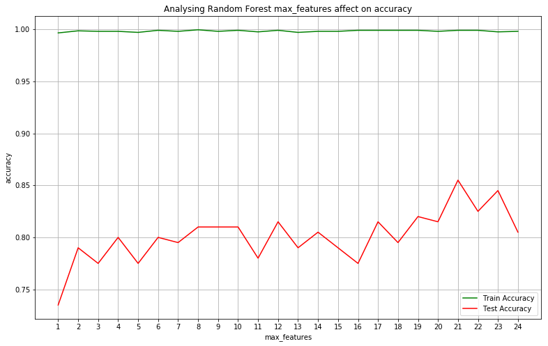

```python
max_features = range(1, 25)
train_accuracy = []
test_accuracy = []
print("Random Forest accuracy score")
for m in max_features:
    rf = RandomForestClassifier(n_estimators=10, max_features=m)
    rf.fit(train_data, train_label)

    pred = rf.predict(train_data)
    train_accuracy.append(accuracy_score(train_label, pred))

    pred = rf.predict(test_data)
    test_accuracy.append(accuracy_score(test_label, pred))

    print("\tmax_feature:", m, "train:", train_accuracy[-1], "test:", test_accuracy[-1])

plt.figure(figsize=(13,8))
plt.plot(max_features, train_accuracy, '-r', label='Train Accuracy', c='green')
plt.plot(max_features, test_accuracy, '-r', label='Test Accuracy', c='red')
plt.xticks(max_features)
plt.xlabel("max_features")
plt.ylabel("accuracy")
plt.title('Analysing Random Forest max_features affect on accuracy')
plt.legend()
plt.grid()
plt.show()
```

 ۱۶- طبق نتایج به دست آمده در اجرا‌های بالا، برای جنگل با n_estimators=1 ما با دقت ۸۶٪ روی داده‌ی train و دقت ۶۰٪ روی داده‌ی test روبه‌رو هستیم که این اعداد برای درخت تصمیم دقت ۱۰۰٪ روی داده‌ی train و دقت ۷۲٪ روی داده‌ی test را داشت. بنابراین این دو مدل معادل هم نیستند چرا که ما در جنگل پارامتر رندوم را نیز تا حدی در کار وارد می‌کنیم. همچنین دیتای train در درخت تصمیم، کل داده است اما در جنگل ما بخشی از داده را برای train استفاده می‌کنیم. لذا نتایج متفاوتی را می‌بینیم.

### Logistic Regression

 ۱۷- این یک روشی است که برای متغیرهای دو سویی مورد استفاده قرار می‌گیرد مثلا مرگ و یا زندگی. در این روش ابتدا رگرسیون عادی که در کلاس نیز مطرح شد به دست می‌آید، سپس خروجی آن به تابع زیر داده می‌شود که باعث گروه‌بندی بهتر می‌شود:  
y = 1 / ( 1 + e^(-x) )

 ۱۸- حل مسئله با این روش

```python
from sklearn.linear_model import LogisticRegression

lr = LogisticRegression()
lr.fit(train_data, train_label)

pred = lr.predict(train_data)
train_accuracy = accuracy_score(train_label, pred)

pred = lr.predict(test_data)
test_accuracy = accuracy_score(test_label, pred)

print("Logistic Regression accuracy score")
print("\ttrain:", train_accuracy, "test:", test_accuracy)
```

```
Logistic Regression accuracy score
	train: 1.0 test: 0.785
```

### K-Means

 ۱۹- این روش خوشه‌بندی با هدف تجزیه n مشاهده به k خوشه است. به این گونه که به اندازه‌ی تعداد دسته‌هایی که مشخص می‌کنیم، سعی می‌کنیم داده‌ها را به آن گروه‌ها تقسیم کنیم به طوری که گروه هر داده، بر اساس نزدیکی آن داده به نزدیک‌ترین مرکز خوشه‌ به دست می‌آید.

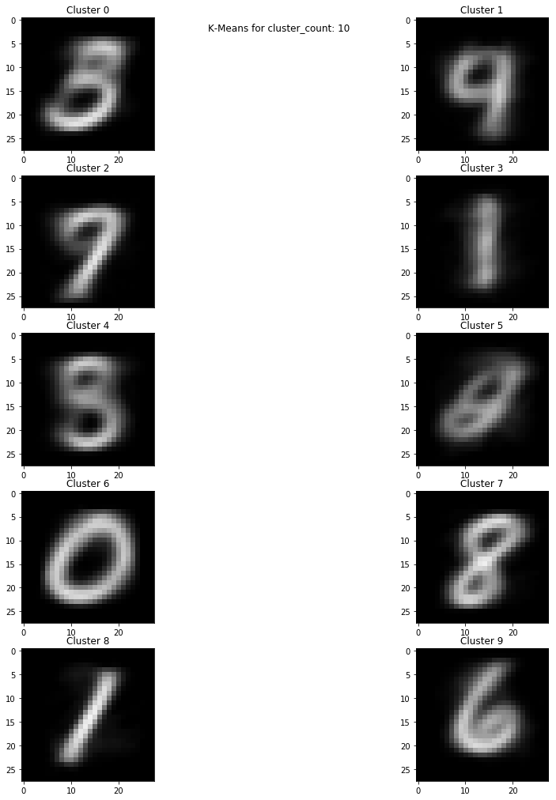

```python
from sklearn.cluster import KMeans

cluster_counts = [10]
accuracy = []
def create_k_means(data, cluster_count):
    km = KMeans(n_clusters=cluster_count)
    km.fit(data)

    fig, axs = plt.subplots(cluster_count//2, 2, figsize=(14, 14))
    fig.tight_layout()
    fig.suptitle("K-Means for cluster_count: {}".format(cluster_count))
    for i, center in enumerate(km.cluster_centers_):
        img = Image.new('L', (28, 28))
        img.putdata(center)
        axs[i//2, i%2].set_title('Cluster {}'.format(i))
        axs[i//2, i%2].imshow(img)

    return km

km = create_k_means(train_data, cluster_count=cluster_counts[-1])
```

 ۲۱- به کمک دسته‌های به دست آمده، دقت روی داده‌های تست را به دست می‌آورم:

```python
import numpy as np

def k_means_accuracy_score(k_means, data, labels, cluster_count):
    cluster_answers = [[0 for j in range(10)] for i in range(cluster_count)]

    for i, data in data.iterrows():
        predict_me = np.array(data)
        predict_me = predict_me.reshape(-1, len(predict_me))
        prediction = k_means.predict(predict_me)

        answer_index = labels.iloc[i]
        cluster_answers[prediction[0]][answer_index] += 1

    print_cluster_answers(cluster_answers)

    correct_answer = sum(map(max, cluster_answers))
    return correct_answer / len(test_data)

def print_cluster_answers(cluster_answers):
    correct_answers = list(map(max, cluster_answers))
    print("\tcluster mapping:")
    for i, cluster_answer in enumerate(cluster_answers):
        correct_number = cluster_answer.index(correct_answers[i])
        print("\t\tcluster", i, "-> number:", correct_number)


print("K-Means accuracy score")
accuracy.append(k_means_accuracy_score(km, test_data, test_label, cluster_count=cluster_counts[-1]))
print("\tcluster_count:", 10, "accuracy:", accuracy[-1])
```

```
K-Means accuracy score
	cluster mapping:
		cluster 0 -> number: 2
		cluster 1 -> number: 4
		cluster 2 -> number: 7
		cluster 3 -> number: 1
		cluster 4 -> number: 8
		cluster 5 -> number: 2
		cluster 6 -> number: 0
		cluster 7 -> number: 8
		cluster 8 -> number: 1
		cluster 9 -> number: 6
	cluster_count: 10 accuracy: 0.53
```

 ۲۲- دسته‌ها را افزایش می‌دهم تا تاثیر آن‌ها را ببینیم:

```
K-Means accuracy score
	cluster mapping:
		cluster 0 -> number: 1
		cluster 1 -> number: 8
		cluster 2 -> number: 0
		cluster 3 -> number: 5
		cluster 4 -> number: 8
		cluster 5 -> number: 3
		cluster 6 -> number: 0
		cluster 7 -> number: 6
		cluster 8 -> number: 7
		cluster 9 -> number: 4
		cluster 10 -> number: 2
		cluster 11 -> number: 1
	cluster_count: 12 accuracy: 0.585
	cluster mapping:
		cluster 0 -> number: 7
		cluster 1 -> number: 7
		cluster 2 -> number: 6
		cluster 3 -> number: 0
		cluster 4 -> number: 2
		cluster 5 -> number: 8
		cluster 6 -> number: 8
		cluster 7 -> number: 4
		cluster 8 -> number: 1
		cluster 9 -> number: 6
		cluster 10 -> number: 3
		cluster 11 -> number: 5
		cluster 12 -> number: 2
		cluster 13 -> number: 1
		cluster 14 -> number: 4
		cluster 15 -> number: 0
	cluster_count: 16 accuracy: 0.675
	cluster mapping:
		cluster 0 -> number: 2
		cluster 1 -> number: 4
		cluster 2 -> number: 1
		cluster 3 -> number: 7
		cluster 4 -> number: 4
		cluster 5 -> number: 0
		cluster 6 -> number: 1
		cluster 7 -> number: 6
		cluster 8 -> number: 7
		cluster 9 -> number: 0
		cluster 10 -> number: 5
		cluster 11 -> number: 8
		cluster 12 -> number: 7
		cluster 13 -> number: 3
		cluster 14 -> number: 6
		cluster 15 -> number: 8
		cluster 16 -> number: 2
		cluster 17 -> number: 2
		cluster 18 -> number: 4
		cluster 19 -> number: 3
	cluster_count: 20 accuracy: 0.635
```

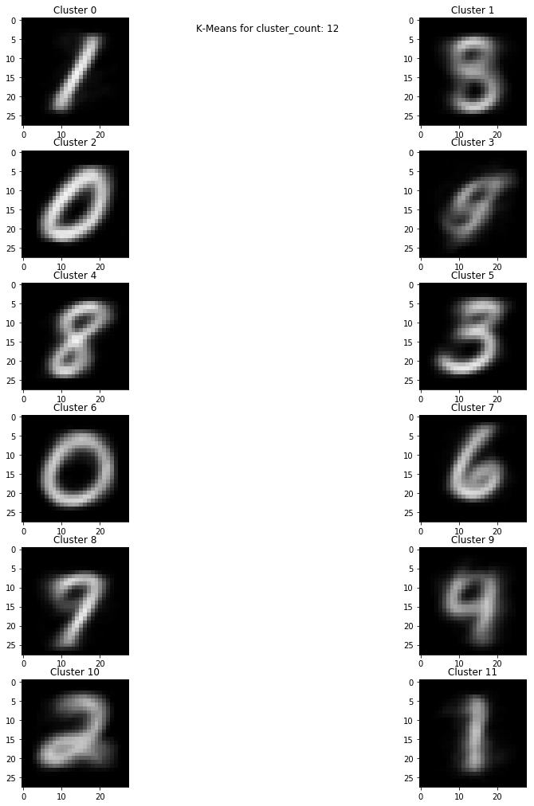

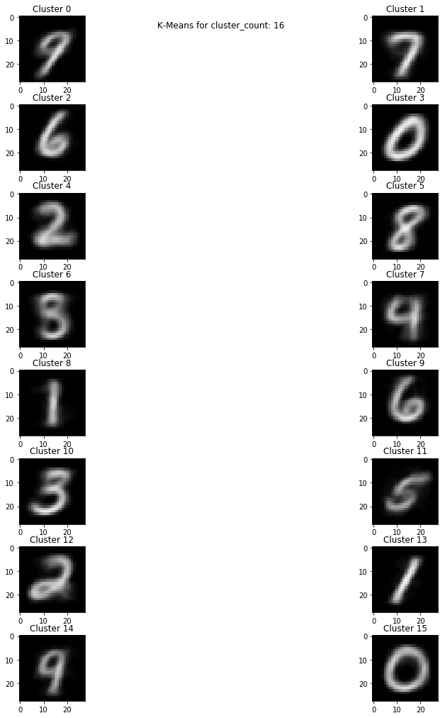

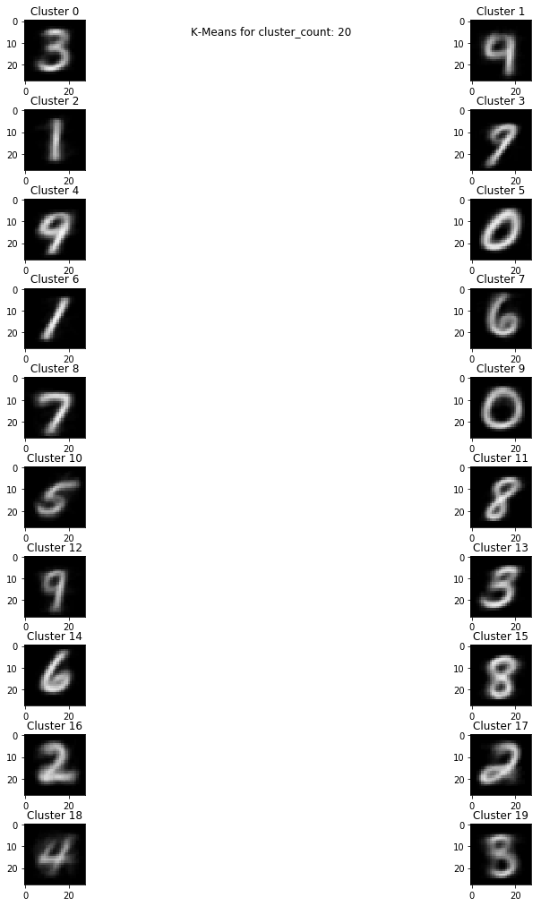

```python
cluster_counts.append(12)
cluster_counts.append(16)
cluster_counts.append(20)

print("K-Means accuracy score")
for cluster_count in cluster_counts[1:]:
    km = create_k_means(train_data, cluster_count)
    accuracy.append(k_means_accuracy_score(km, test_data, test_label, cluster_count))
    print("\tcluster_count:", cluster_count, "accuracy:", accuracy[-1])
```

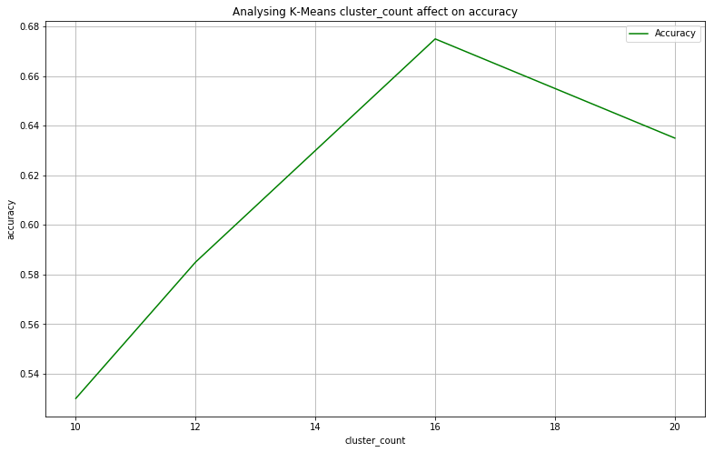

```python
plt.figure(figsize=(13,8))
plt.plot(cluster_counts, accuracy, '-r', label='Accuracy', c='green')
plt.xlabel("cluster_count")
plt.ylabel("accuracy")
plt.title('Analysing K-Means cluster_count affect on accuracy')
plt.legend()
plt.grid()
plt.show()
```

 ۲۳- زمان پاسخ k-means بر روی داده‌های جدید بهتر است چرا که خوشه‌ها قبلا به وسیله‌ی داد‌ه‌ی train ایجاد شده‌اند و برای هر داده کافی‌ است نزدیک‌ترین مرکز خوشه به آن را پیدا کنیم. اما در KNN، در فاز train صرفا داده‌ها ذخیره می‌شد و هیچ پردازشی روی‌ آن‌ها صورت نمی‌گرفت و همه‌‌ی بار پردازشی در فاز تست انجام می‌شد که فرایند کندی بود.

### جمع‌بندی انواع الگوریتم‌های دسته بندی

 ۲۴- بیشترین دقت بر روی ورودی مربوط به الگوریتم KNN با k=12 می‌شد که دقت ۹۱٪ را روی داده‌ی train و test داشت.

 ۲۵- برای الگوریتم KNN با k=12، من confusion matrix را رسم می‌کنم:

```
K-Nearest Neighbors accuracy score
	For n_neighbors = 12 train: 0.9145 test: 0.91
```

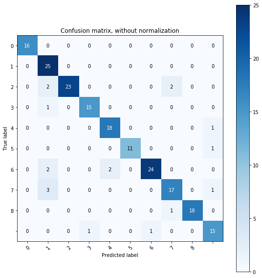

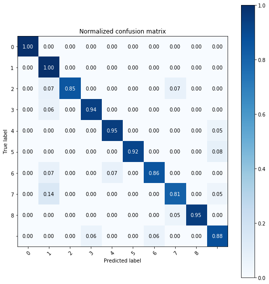

```python
from sklearn.metrics import confusion_matrix

neigh = KNeighborsClassifier(n_neighbors=12)
neigh.fit(train_data, train_label)

pred = neigh.predict(train_data)
train_accuracy = accuracy_score(train_label, pred)

pred = neigh.predict(test_data)
test_accuracy = accuracy_score(test_label, pred)

print ("K-Nearest Neighbors accuracy score")
print ("\tFor n_neighbors =", 12, "train:", train_accuracy, "test:", test_accuracy)

def plot_confusion_matrix(y_true, y_pred, classes, normalize=False, title=None, cmap=plt.cm.Blues):
    """
    This function prints and plots the confusion matrix.
    Normalization can be applied by setting `normalize=True`.
    """
    # Compute confusion matrix
    cm = confusion_matrix(y_true, y_pred)

    if normalize:
        cm = cm.astype('float') / cm.sum(axis=1)[:, np.newaxis]

    fig, ax = plt.subplots(figsize=(8, 8))
    im = ax.imshow(cm, interpolation='nearest', cmap=cmap)
    ax.figure.colorbar(im, ax=ax)
    # We want to show all ticks...
    ax.set(xticks=np.arange(cm.shape[1]),
           yticks=np.arange(cm.shape[0]),
           # ... and label them with the respective list entries
           xticklabels=classes, yticklabels=classes,
           title=title,
           ylabel='True label',
           xlabel='Predicted label')

    # Rotate the tick labels and set their alignment.
    plt.setp(ax.get_xticklabels(), rotation=45, ha="right", rotation_mode="anchor")

    # Loop over data dimensions and create text annotations.
    fmt = '.2f' if normalize else 'd'
    thresh = cm.max() / 2.
    for i in range(cm.shape[0]):
        for j in range(cm.shape[1]):
            ax.text(j, i, format(cm[i, j], fmt),
                    ha="center", va="center",
                    color="white" if cm[i, j] > thresh else "black")
    fig.tight_layout()
    return ax

class_names = range(0, 9)

# Plot non-normalized confusion matrix
plot_confusion_matrix(test_label, pred, classes=class_names, title='Confusion matrix, without normalization')

# Plot normalized confusion matrix
plot_confusion_matrix(test_label, pred, classes=class_names, normalize=True, title='Normalized confusion matrix')

plt.show()
```

 ۲۶- سعی می‌کنم داده‌ای را پیدا کنم که در الگوریتم KNN و Logistic Regression مقدار متفاوتی داشته:

```
test data index 2 is 5 but predicted 8
```

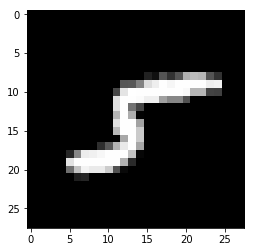

```python
lr_pred = lr.predict(test_data)
knn_pred = neigh.predict(test_data)

for i, predication in enumerate(knn_pred):
    correct_value = test_label.iloc[i]
    if predication == correct_value:
        if predication != lr_pred[i]:
            print("test data index", i, "is", correct_value, "but predicted", lr_pred[i])
            img = Image.new('L', (28, 28))
            img.putdata(test_data.iloc[i])
            plt.imshow(img)
            break
```

 داده‌ی فوق که عدد ۵ است در KNN درست پیشبینی شده ولی در Logistic Regression اشتباها ۸ پیشبینی شده است.

### کاهش ابعاد بردار ویژگی‌ها

 ۲۷- PCA تبدیلی در فضای برداری است که برای کاهش ابعاد مجموعه‌ی داده مورد استفاده قرار می‌گیرد. عملکرد آن به این صورت است که داده را به دستگاه مختصات جدید می‌برد به طوری که بزرگ‌ترین واریانس داده بر روی اولین محور مختصات، دومین بزرگ‌ترین واریانس بر روی دومین محور قرار می‌گیرد و همین‌طور تا آخر؛ بنابراین با این کار مولفه‌هایی که بیشترین تاثیر را روی داده دارند، حفظ می‌شوند.  
 در هنگامی که ما با داده‌ای روبه‌رو هستیم که ابعاد (فیچرهای) زیادی دارد که از لحاظ اندازه نیز با هم متفاوت هستند، از PCA استفاده می‌کنیم چرا که چشم‌انداز بهتر و پیچیدگی کمتری از داده به ما می‌دهد و با کاهش بعد به دو یا سه می‌توانیم بهتر داده‌ها را مدل و visualize کنیم. حجم داده‌ها نیز کاهش میابد.

```python
from sklearn.decomposition import PCA

pca = PCA(n_components=20)
principal_train_components = pca.fit_transform(train_data)
principal_test_components = pca.transform(test_data)

neigh = KNeighborsClassifier(n_neighbors=12)
neigh.fit(principal_train_components, train_label)

pred = neigh.predict(principal_train_components)
train_accuracy = accuracy_score(train_label, pred)

pred = neigh.predict(principal_test_components)
test_accuracy = accuracy_score(test_label, pred)

print ("K-Nearest Neighbors accuracy score for PCA data")
print ("\tFor n_neighbors =", 12, "train:", train_accuracy, "test:", test_accuracy)
```

```
K-Nearest Neighbors accuracy score for PCA data
	For n_neighbors = 12 train: 0.934 test: 0.93
```

 دقت بدون PCA در روش KNN حدود ۹۱٪ بود ولی با استفاده از این روش به دقت ۹۳٪ رسیدم که حدود ۲٪ بیشتر شده. دلیل آن را می‌توان به مفیدتر شدن اطلاعات با کاهش بعد و نگه‌نداشتن اطلاعات بی‌ ارزش مانند اطلاعات پیکسل‌های حاشیه‌ای اشاره کرد.